# Exploratory Data Analysis of Palmer Penguins

### How does the bill vary between species ?

- You can give color to different species to see the underlying patterns.

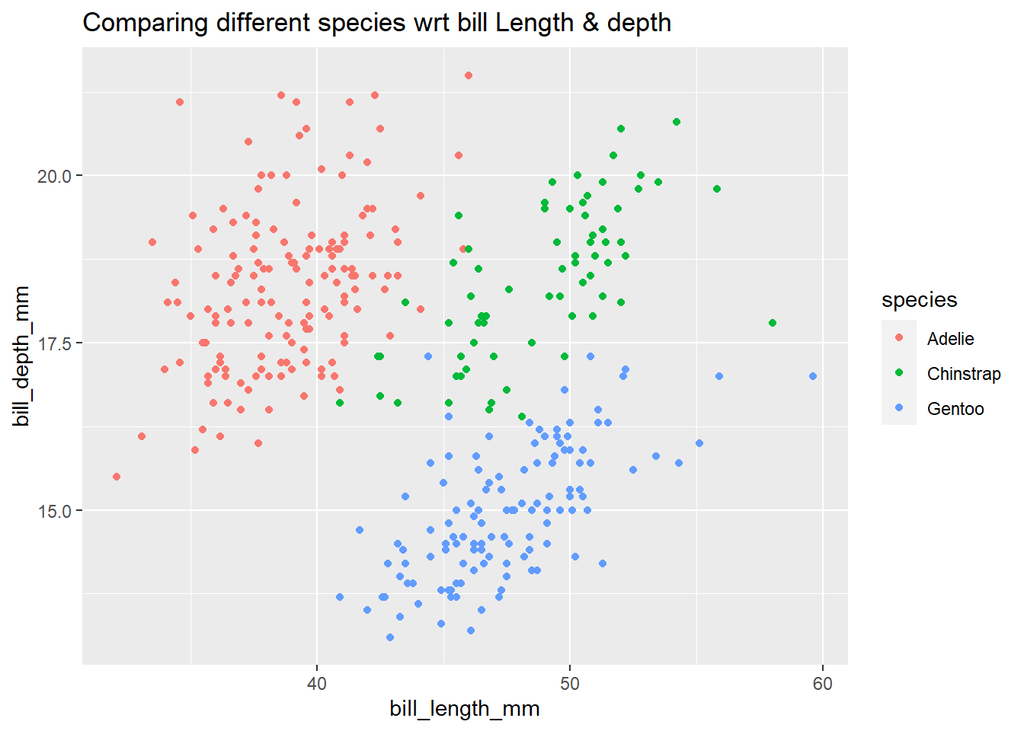

```r
penguins%>%
  ggplot()+
  geom_point(mapping = aes(x=bill_length_mm,y=bill_depth_mm,color=species),shape=16)+
  ggtitle("Comparing different species wrt bill Length & depth")
```

- shape argument assigns shapes to these points. If you dont want a dot you can choose the code shown below to pick any particular shape you want.

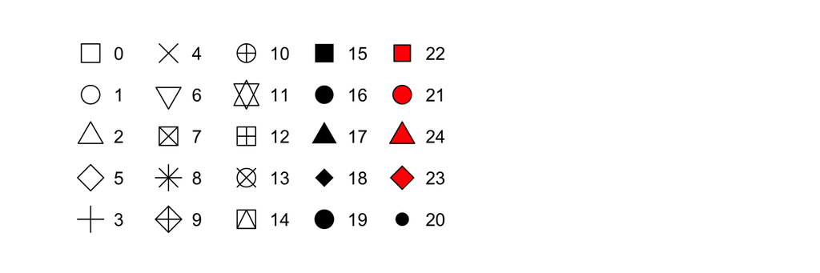

Code for choosing shape in ggplot

### What do you gather from this?

# Conclude

Feel free to explore further and conclude important findings here.

# References

It is important that you credit the original authors of the R packages or any sources you have used to create this report.

For citing R packages, you can use the function `citation(packagename)`.

- Horst AM, Hill AP, Gorman KB (2020). palmerpenguins: Palmer Archipelago (Antarctica) penguin data. R package version 0.1.0. https://allisonhorst.github.io/palmerpenguins/
- Wickham et al., (2019). Welcome to the tidyverse. Journal of Open Source Software, 4(43), 1686, https://doi.org/10.21105/joss.01686